# WHO COVID-19 Data Analysis: the ‘weekend effect’ in US and world

Tina Tan 914650494

03/12/2022

## I. Introduction

It had several articles and news reported that there was a “weekend effect” in COVID-19 cases and mortality. According to ABC News, the Ohio Department of Health found that the number of new cases reported was lowest on the weekends, and then the cases would rise throughout the week, often peaking on Friday. Meanwhile, professor Lauren Hale from Public Health at Stony Brook University School of Medicine also observed this “weekend effect” weekly cycles occurring in the US and other countries. Professor Lauren stated the reason for the “weekend effect” occurring would including:1) fewer people getting tested on the weekends; 2) fewer lab tests process on the weekends; 3) delay in reporting lags on weekends; 4) weekend lead to more initial symptoms on weekdays. In this report, I utilized the WHO COVID-19 data to extent the similar research and see if “weekend effect” also occurs in whole U.S. and even the world regions.

## II.Data Backgroud and Overview

1. Date_reproted: data of reported (year-month-day)
2. Country_code: short alphabetic or numeric geographical codes
3. Country name
4. WHO_regin: African Region (AFR), Region of the Americas (AMR), South-East Asian Region (SEAR), European Region (EUR), Eastern Mediterranean Region (EMR), and Western Pacific Region (WPR)
5. New_cases: number of new cases on the reported date
6. Cumulative cases: cumulative cases by the reported date
7. New_deaths: number of new deaths on the reported date
8. Cumulative_deathes: cumulative deathes by the reported date

```
## # A tibble: 189,272 × 8
##    Date_reported Country_code Country     WHO_region  New_cases Cumulative_cases
##    <date>        <chr>        <chr>       <fct>           <dbl>            <dbl>
##  1 2020-01-03    AF           Afghanistan Eastern Me…         0                0
##  2 2020-01-04    AF           Afghanistan Eastern Me…         0                0
##  3 2020-01-05    AF           Afghanistan Eastern Me…         0                0
##  4 2020-01-06    AF           Afghanistan Eastern Me…         0                0
##  5 2020-01-07    AF           Afghanistan Eastern Me…         0                0
##  6 2020-01-08    AF           Afghanistan Eastern Me…         0                0
##  7 2020-01-09    AF           Afghanistan Eastern Me…         0                0
##  8 2020-01-10    AF           Afghanistan Eastern Me…         0                0
##  9 2020-01-11    AF           Afghanistan Eastern Me…         0                0
## 10 2020-01-12    AF           Afghanistan Eastern Me…         0                0
## # … with 189,262 more rows, and 2 more variables: New_deaths <dbl>,
## #   Cumulative_deaths <dbl>
```

### New Cases

The spaghetti plot below briefly showed the total daily New_cases for each WHO_region that provided an overview of the daily new cases trends. In this case, the WHO_region was treated as the basic unit during analysis. The New_case of countries from the same region would be summed up and then compared to each other.

```
## # A tibble: 6 × 3
## # Groups:   Date_reported [1]
##   Date_reported WHO_region            sum_newcases
##   <date>        <fct>                        <dbl>
## 1 2020-01-03    Africa                           0
## 2 2020-01-03    Americas                         0
## 3 2020-01-03    Eastern Mediterranean            0
## 4 2020-01-03    Europe                           0
## 5 2020-01-03    South-East Asia                  0
## 6 2020-01-03    Western Pacific                  0
```

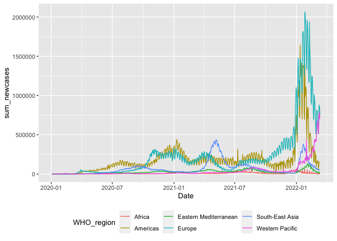

### Case-mortality Rate

```
## # A tibble: 6 × 5
##   Date_reported WHO_region    Cumulative_cases Cumulative_deat… Case_mortality_…
##   <date>        <fct>                    <dbl>            <dbl>            <dbl>
## 1 2020-01-03    Eastern Medi…                0                0                0
## 2 2020-01-04    Eastern Medi…                0                0                0
## 3 2020-01-05    Eastern Medi…                0                0                0
## 4 2020-01-06    Eastern Medi…                0                0                0
## 5 2020-01-07    Eastern Medi…                0                0                0
## 6 2020-01-08    Eastern Medi…                0                0                0
```

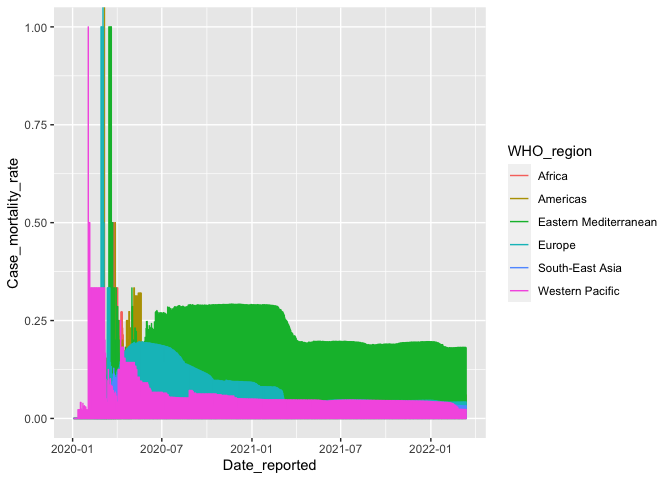

## III. Descriptive analysis - WHO COVID-19

The following dataset “covid” would be used to analyze whether the “weekend effect” also coccus in US and world. The dataset selected the related variables from original data set. Also, it was added new column “Weekday_or_Weekend” in the selected data frame as indicators to determine the date if it is a weekend or not. (Weekend = TRUE, Weekday = FALSE)

```
## # A tibble: 6 × 5
##   Date_reported WHO_region            Country     New_cases Weekday_or_Weekend
##   <date>        <fct>                 <chr>           <dbl> <lgl>
## 1 2020-01-03    Eastern Mediterranean Afghanistan         0 FALSE
## 2 2020-01-04    Eastern Mediterranean Afghanistan         0 TRUE
## 3 2020-01-05    Eastern Mediterranean Afghanistan         0 TRUE
## 4 2020-01-06    Eastern Mediterranean Afghanistan         0 FALSE
## 5 2020-01-07    Eastern Mediterranean Afghanistan         0 FALSE
## 6 2020-01-08    Eastern Mediterranean Afghanistan         0 FALSE
```

## VI. USA: Descriptive and Inferetial analysis

### Descriptive analysis

```
## # A tibble: 6 × 5
##   Date_reported WHO_region Country                  New_cases Weekday_or_Weekend
##   <date>        <fct>      <chr>                        <dbl> <lgl>
## 1 2021-01-01    Americas   United States of America    237536 FALSE
## 2 2021-01-02    Americas   United States of America    229181 TRUE
## 3 2021-01-03    Americas   United States of America    227548 TRUE
## 4 2021-01-04    Americas   United States of America    226218 FALSE
## 5 2021-01-05    Americas   United States of America    204647 FALSE
## 6 2021-01-06    Americas   United States of America    175024 FALSE
```

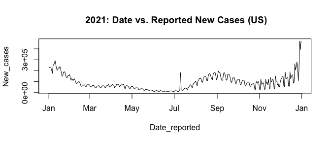

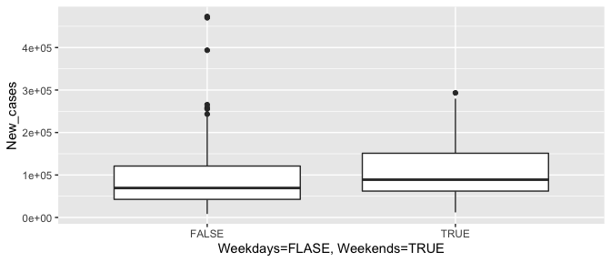

### Data transformation

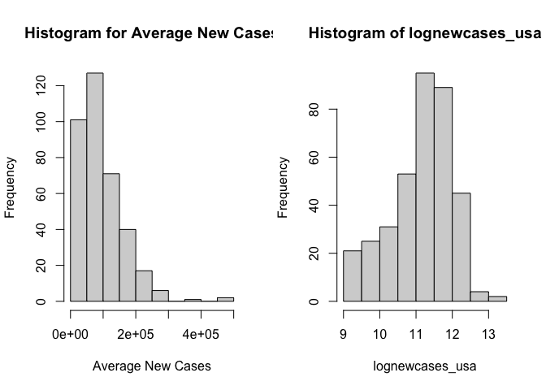

### Inferential analysis

```
##                        Estimate Std. Error   t value     Pr(>|t|)
## (Intercept)            88138.52   4256.174 20.708391 1.881352e-63
## Weekday_or_WeekendTRUE 17079.58   7973.503  2.142043 3.285496e-02
```

i.e.

$$y_{ij}=\alpha+\beta*x_{wk}+\epsilon_{ij}$$

where,

$$\begin{align*}
\hat\alpha&\approx 88138.52 \\
\hat\beta_1&\approx 17079.58 \\
\end{align*}$$

Then, running a one-way ANOVA.

$$\mathrm{H0:There\ is\ NO \ difference\ in \ the\ daily \ new \ cases \ between \ weekend \ and \ weekday \ in \ USA.}$$
$$\mathrm{H1:There\ is\ a \ difference\ in \ the\ daily \ new \ cases \ between \ weekend \ and \ weekday \ in \ USA.}$$

```
## Analysis of Variance Table
##
## Response: New_cases
##                     Df     Sum Sq    Mean Sq F value  Pr(>F)
## Weekday_or_Weekend   1 2.1694e+10 2.1694e+10  4.5883 0.03285 *
## Residuals          363 1.7163e+12 4.7280e+09
## ---
## Signif. codes:  0 '***' 0.001 '**' 0.01 '*' 0.05 '.' 0.1 ' ' 1
```

From the output of one-way ANOVA, we could see that Weekday_or_Weekend explained a significant variation in the new cases since its p-values less than 0.05. Hence, in this case, we could conclude that the daily new case related to weekend and weekday in the USA.

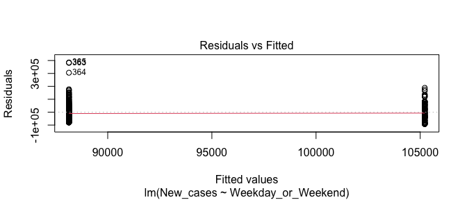

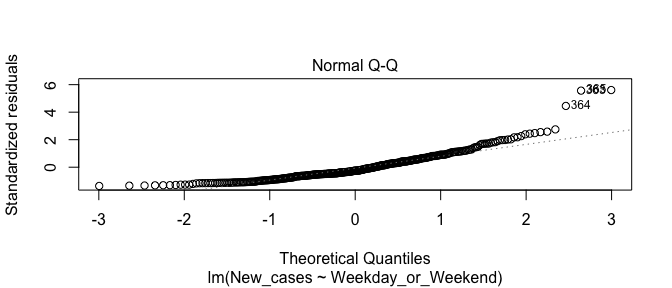

As seen in the Observed vs Fitted values plot, all data points fall into the clusters on two sides since our predictor “Weekday_or_Weekend” was binary variable. On the other, we can use the QQ-plot for checking the normality. From the above QQ-plot, main points are located around the theoretical dash line that showing $\epsilon_{ij}$ are roughly normally distrusted.But it still have heavy tail at the end.

## VI. All Country (World): Descriptive and Inferetial analysis

### Descriptive analysis

```
## # A tibble: 2 × 2
##   Weekday_or_Weekend  mean
##   <lgl>              <dbl>
## 1 FALSE              2372.
## 2 TRUE               2551.
```

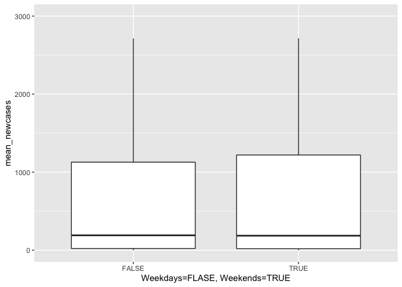

```
## # A tibble: 6 × 3
## # Groups:   Country [6]
##   Country                   Weekday_or_Weekend mean_newcases
##   <chr>                     <lgl>                      <dbl>
## 1 Saint Barthélemy          FALSE                       1.16
## 2 Saint Pierre and Miquelon FALSE                       1.52
## 3 Kiribati                  TRUE                        2.35
## 4 Anguilla                  TRUE                        2.70
## 5 Saint Martin              FALSE                       2.79
## 6 Tonga                     FALSE                       3.15
```

### Data transformation

In this case, before fit a model for analyzing, I would like to use the log transformation to make data normality since the histogram had a right skewed.

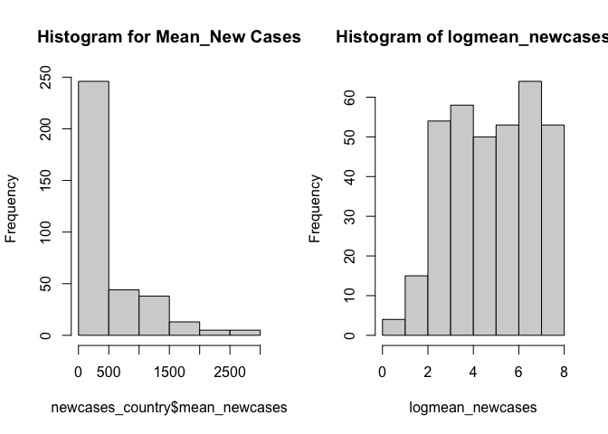

### Inferential analysis

```
##                           Estimate Std. Error    t value      Pr(>|t|)
## (Intercept)             4.82211986  0.1390530 34.6782920 4.148963e-115
## Weekday_or_WeekendTRUE -0.04693072  0.1974964 -0.2376282  8.123089e-01
```

Next, we fit a regression a full linear model involving log(mean_newcases) as response variable on the predictors “Weekday_or_Weekend”.

i.e.

$$y_{ij}=\alpha+\beta*x_{wk}+\epsilon_{ij}$$

where,

$$\begin{align*}
\hat\alpha&\approx 4.82211986 \\
\hat\beta_1&\approx -0.04693072 \\
\end{align*}$$

Then, tuning a one-way ANOVA.

$$\mathrm{H0:There\ is\ NO \ difference\ in \ the\ global \ daily \ new \ cases \ between \ weekend \ and \ weekday.}$$
$$\mathrm{H1:There\ is\ a \ difference\ in \ the\ global \ daily \ new \ cases \ between \ weekend \ and \ weekday.}$$

```
##                     Df Sum Sq Mean Sq F value Pr(>F)
## Weekday_or_Weekend   1    0.2   0.193   0.056  0.812
## Residuals          349 1194.4   3.422
```

From the output of one-way ANOVA, we could see that Weekday_or_Weekend did not explains a significant variation in the new cases since its p-values much greater than 0.05. Hence, in this case, we could conclude global daily new case not related to weekend and weekday.

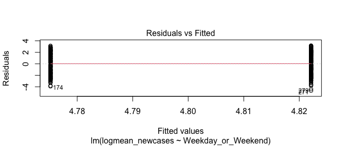

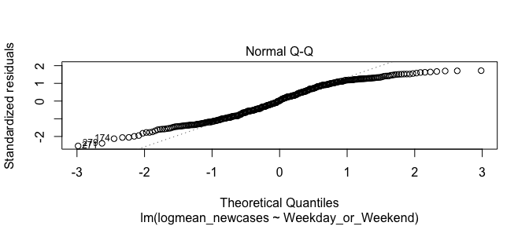

As seen in the Observed vs Fitted values plot, all data points fall into the clusters on two sides since our predictor “Weekday_or_Weekend” was binary variable. On the other, we can use the QQ-plol for checking the normality. From the above QQ-plot, main points were NOT located around the theoretical dash line that showing $\epsilon_{ij}$ are roughly normally distrusted.But it still have heavy tail at both sides.

# IV. Conclusion

At the beginning of the report, we regenerated the data by grouping the daily new cases with the WHO region. Also, we used True or False to determine whether the date was weekend or not. We were interested in if there is a difference in new cases between weekday and weekend in USA and whole world.

We used a one-way ANOVA test to check if there is a difference in new cases between weekdays and weekends in the USA and even the whole world. From the ANOVA test, Weekday_or_Weekend explained a significant variation in the new cases in the USA. But it was not present “Weekend Effect” since the boxplot showing the weekend had a higher average daily cases than a weekday. On the other hand, there is not enough evidence to prove there is a “Weekend Effect” globally, and the analysis model did not hold any assumption. In the future, I think we should try adding more predictors to see whether other conditions may affect new cases, for example, income, population, vaccination, etc.

# Reference

1. Cross, I. (2021, September 29). There’s a reason why daily COVID cases are lower on weekends and higher during the Week. WEWS. Retrieved February 18, 2022, from https://www.news5cleveland.com/news/continuing-coverage/coronavirus/theres-a-reason-why-daily-covid-cases-are-lower-on-weekends-and-higher-during-the-week
2. Hale, L. (2020, December 19). Why are covid-19 numbers lower on the weekends? Dear Pandemic. Retrieved February 18, 2022, from https://dearpandemic.org/covid-19-numbers-lower-on-the-weekends/
3. Lonzerj. (2020, November 11). The weekend effect and covid-19 mortality. Consult QD. Retrieved February 18, 2022, from https://consultqd.clevelandclinic.org/the-weekend-effect-and-covid-19-mortality/?fbclid=IwAR0qDj-8JNeg68ggK9zH_Xplnoh0W0VxAQfERi2CgYBk-VTho06RyIgqjWc

# Appendix: All code for this report

```r
library(tidyverse)
library(gridExtra)
library(scales)
library(lubridate)
library(ggplot2)
library(haven)
library(MASS)
library(knitr)
## Load WHO COVID-19 dataset
covid <- read_csv("https://covid19.who.int/WHO-COVID-19-global-data.csv")

covid <- covid %>%
  filter(WHO_region != "Other") %>%
  mutate(WHO_region = fct_recode(WHO_region,"Eastern Mediterranean"="EMRO","Europe" = "EURO","Africa" = "AFRO","Western Pacific" = "WPRO","Americas"="AMRO","South-East Asia" = "SEARO"))
covid
## Overview
## Obtain daily New_cases in the world by WHO_region
newcases_regions<-covid %>%
          group_by(Date_reported,WHO_region) %>%
          summarise(sum_newcases=sum(New_cases))
head(newcases_regions)


## Spaghetti plot
(linegraph<- newcases_regions %>% filter(Date_reported>= "2020-01-03", Date_reported<= "2022-03-12") %>%
  mutate(Date=as.Date(Date_reported)) %>%
  ggplot(aes(x=Date,y=sum_newcases,by=WHO_region)) +
  geom_line(aes(color=WHO_region)) +
  theme(legend.position ='bottom'))
## Calculate case-mortality rate
covidmortality<-covid[c("Date_reported", "WHO_region", "Cumulative_cases", "Cumulative_deaths")]
covidmortality <- covidmortality %>%
  add_column(Case_mortality_rate = (covidmortality$Cumulative_deaths)/(covidmortality$Cumulative_cases),
             .after = "Cumulative_deaths")

covidmortality[is.na(covidmortality)] <- 0
head(covidmortality)

ggplot(data = covidmortality, aes(x = Date_reported, y = Case_mortality_rate, by = WHO_region)) +
  geom_line(aes(color=WHO_region))

## Select the interested variables
covid<-covid[c("Date_reported", "WHO_region", "Country", "New_cases")]

## Determine if date is a weekend or not
## Weekend(Sat&Sun) = TRUE, Weekday(Mon-Fri) = FALSE
library(lubridate);library(chron)
wkend<-is.weekend(covid$Date_reported)

## Add columns in dataframe
covid<- covid %>%
  add_column("Weekday_or_Weekend"= if_else(wkend, TRUE, FALSE))
head(covid)
newcases_usa<-covid %>% filter(Country=="United States of America", Date_reported>= "2021-01-01", Date_reported<= "2021-12-31")
head(newcases_usa)
plot(newcases_usa$Date_reported, newcases_usa$New_cases, xlab = "Date_reported", ylab = "New_cases",main = " 2021: Date vs. Reported New Cases (US)", type = "l")

## Boxplot
ggplot(data=newcases_usa, mapping=aes(x=Weekday_or_Weekend, y=New_cases)) +
  geom_boxplot() +
  xlab("Weekdays=FLASE, Weekends=TRUE")
par(mfrow=c(1,2))
hist(newcases_usa$New_cases,
     main="Histogram for Average New Cases",
     xlab = "Average New Cases")
lognewcases_usa<-log(newcases_usa$New_cases)
hist(lognewcases_usa)
model1<-lm(New_cases~Weekday_or_Weekend, data=newcases_usa)
coef(summary(model1))
anova(model1)
plot(model1, which = 1)
plot(model1, which = 2)
newcases_country<-covid %>%
          group_by(Country,Weekday_or_Weekend) %>%
          summarise(mean_newcases=mean(New_cases))
newcases_country<-newcases_country %>% filter(Country != "Nicaragua")

## mean_newcase: weekday vs.weekend
(mean=newcases_country %>%
  group_by(Weekday_or_Weekend) %>%
  summarise(mean=mean(mean_newcases)))

## Boxplot
ggplot(data=newcases_country, mapping=aes(x=Weekday_or_Weekend, y=mean_newcases)) +
  geom_boxplot(outlier.shape = NA) +
  coord_cartesian(ylim=c(0,3000)) +
  xlab("Weekdays=FLASE, Weekends=TRUE")

## excluding outliers mean_newcases >= 3000 and mean_newcases <= 1 according to boxplot
newcases_country<-newcases_country %>% filter(mean_newcases>= 1, mean_newcases<= 3000)
newcases_country %>% arrange(mean_newcases) %>% head()
par(mfrow=c(1,2))
hist(newcases_country$mean_newcases,
     main="Histogram for Mean_New Cases")

## log transformation
zerocases<-newcases_country$mean_newcases==0
newcases_country$mean_newcases[zerocases] <- 1e-09
logmean_newcases<-log(newcases_country$mean_newcases)
hist(logmean_newcases)
model2<-lm(logmean_newcases~Weekday_or_Weekend, data=newcases_country)
coef(summary(model2))
summary(aov(model2))
plot(model2, which = 1)
plot(model2, which = 2)
```